# Statlearn 2018: Tutorial on HD clustering

Charles Bouveyron - Université Côte d’Azur & Inria

All code and data sets used in this tutorial are avalaible https://github.com/cbouveyron/Statlearn-ClustHD. The required libraries are: *mvtnorm*, *Rmixmod*, *mclust*, *HDclassif* and *FisherEM*. They can be installed using the `install.packages()` command.

# 1 - Curse and blesssing of dimensionality

## 1.1 - The volume of the unit hyper-sphere

Let’s look at the bahavior of the volume of the unit hyper-sphere according to the space dimensionality. Let’s recall that the formulae of the volume of the unit hypers-sphere is
$$V_S(p) = \frac{\pi^{p/2}}{\Gamma(p/2+1)}$$

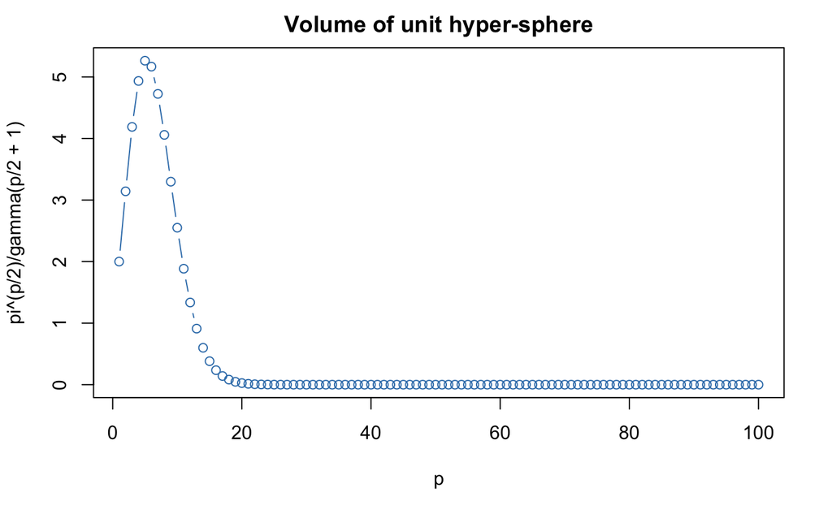

```r
p = 1:100
plot(p,pi^(p/2)/gamma(p/2+1),type='b',col=1)
title(main="Volume of unit hyper-sphere")
```

Another interesting thing in high-dimensional spaces is the empty-space phenomenum. It can be observed by loonking at the 0.9-radius shell. This may in particular be useful for classification and clustering purposes.

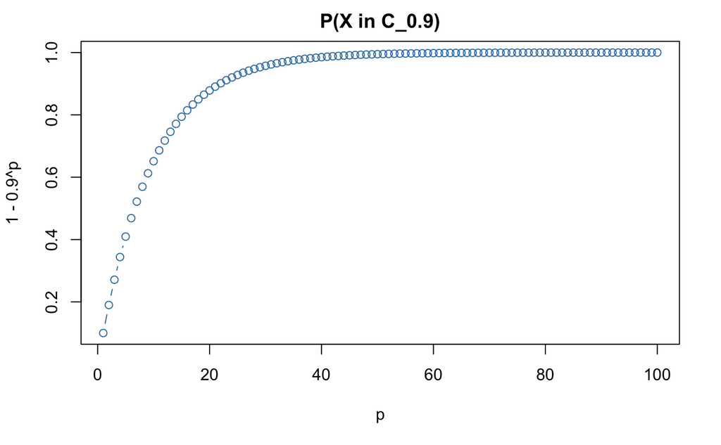

```r
plot(p,1-0.9^p,type='b',col=1)
title(main="P(X in C_0.9)")
```

## 1.3 - Bayes classifier vs EDDA

Warning: may take a while!

```r
library(mvtnorm); library(MASS); library(Rmixmod)
BayesClass <- function(X,tau,m,S){
  G = length(m); d = ncol(X)
  P = matrix(NA,nrow(X),G)
  for (g in 1:G) P[,g] = tau[g] * dmvnorm(X,m[[g]],S[[g]])
  P = P / rowSums(P) %*% matrix(1,1,G)
  list(P = P, cls = max.col(P))
}
n = 120; nbrep = 5
dims = seq(10,210,20)
err = err2 = err3 = matrix(NA,length(dims),nbrep)
for (i in 1:length(dims)){
  cat('.')
  for (j in 1:nbrep){
    # Simulation
    d = dims[i]
    m1 = c(0,0,rep(0,d-2)); m2 = c(0,-2,rep(0,d-2)); m3 = c(2,0,rep(0,d-2));
    S1 = diag(d); S2 = 0.8 * diag(d); S3 = 0.9 * diag(d)
    X = as.data.frame(rbind(mvrnorm(n/3,m1,S1),mvrnorm(n/3,m2,S2),mvrnorm(n/3,m3,S3)))
    X2 = as.data.frame(rbind(mvrnorm(10*n/3,m1,S1),mvrnorm(10*n/3,m2,S2),mvrnorm(10*n/3,m3,S3)))
    cls = rep(1:3,rep(n/3,3))
    cls2 = rep(1:3,rep(10*n/3,3))
    # Classification with the Bayes' classifier
    pred = BayesClass(X2,rep(1/3,3),list(m1,m2,m3),list(S1,S2,S3))
    # Classification with EDDA
    mod = mixmodLearn(X,cls,models=mixmodGaussianModel(listModels = 'Gaussian_pk_Lk_I'))
    res = mixmodPredict(X2,mod["bestResult"])@partition
    # Computing error rate
    err[i,j] = sum(pred$cls != cls2) / length(cls2)
    err2[i,j] = sum(res != cls2) / length(cls2)
  }
}
```

```
...........
```

```r
cat('\n')
```

```r
boxplot(t(err),ylim=c(0.1,0.33),names=dims,xlab='Dimension',ylab='Classification error rate',col=3)
boxplot(t(err2),names=dims,xlab='Dimension',ylab='Classification error rate',col=4,add=TRUE)
```

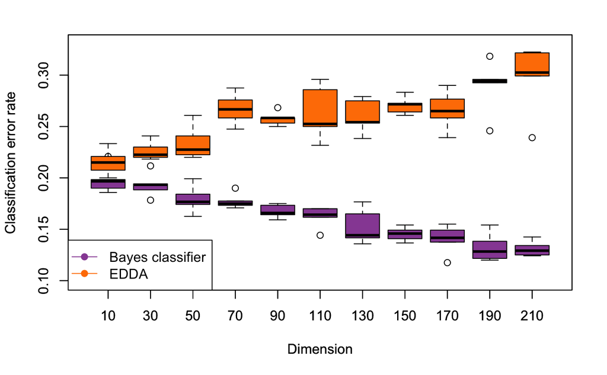

```r
legend("bottomleft",legend = c('Bayes classifier','EDDA'),col=c(3,4),lty=1,pch=19)
```

# 2 - Earlier work

## 2.1 - Principal component analysis

Let’s first look at some real high-dimensional data: the NIR chemometric data (Ruckebusch et al.).

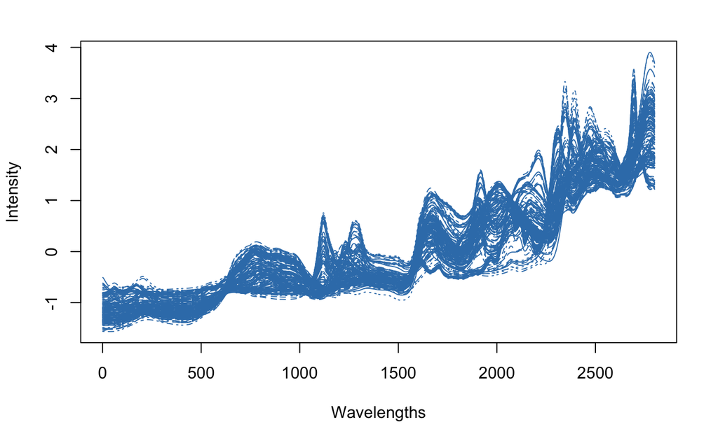

```r
load('data/NIR_data.Rdata')
matplot(t(Y),col=1,type='l',xlab='Wavelengths',ylab='Intensity')
```

In these data, we would like to recover tree different groups of curves. Notice that the actual labels are in the `cls` vector.

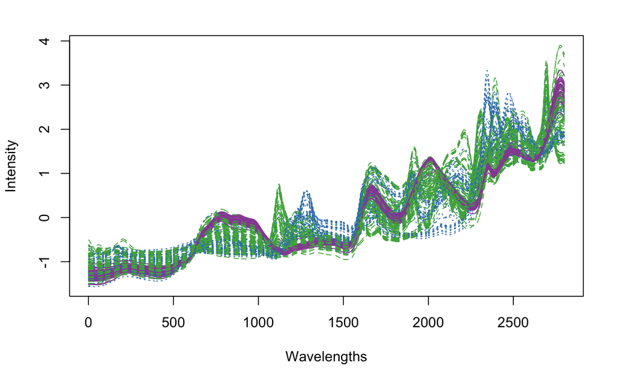

```r
matplot(t(Y),col=cls,type='l',lty=(3:1)[cls],xlab='Wavelengths',ylab='Intensity')
```

Let’s do now a PCA on it and try to figure out which principal axes are the most discriminant.

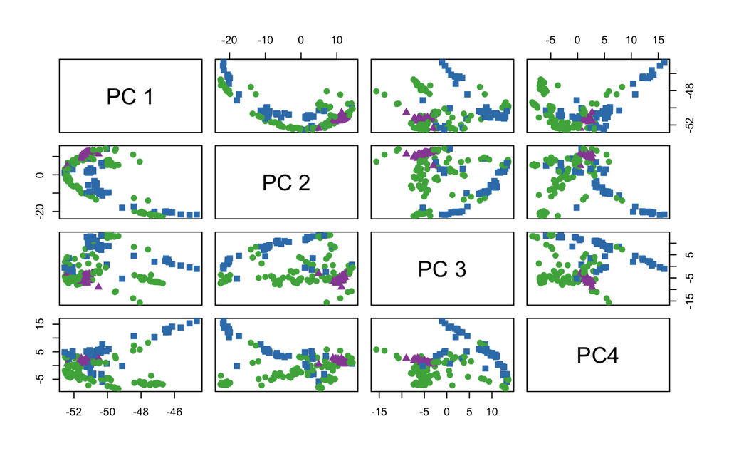

```r
# PCA on the NIR data !!!! TO DO !!!
library(MASS)
U = svd(Y)$v
Yp = as.matrix(Y) %*% U
pairs(Yp[,1:4],col=cls,pch=(15:17)[cls],cex=1.25,labels=c('PC 1','PC 2','PC 3','PC4'))
```

## 2.2 - Mclust on original and PCA axes

Let’s now try to cluster HD data with Mclust (as seen in Julien’s tutorial). To this end, we’ll work with the Wine data set (but in its 27-dimensional version!).

```r
load('data/Wine27.Rdata')
# TO DO!
library(mclust)
out = Mclust(X,G=3,verbose = FALSE)
table(out$classification,cls)
```

```
   cls
     1  2  3
  1 58  1  0
  2  1 70  2
  3  0  0 46
```

```r
adjustedRandIndex(out$classification,cls)
```

```
[1] 0.9306492
```

A triaditional way to avoid the curse of dimensionality is to cluster the projected data on the first principal axes.

```r
# TO DO!
Xp = predict(princomp(X))[,1:2]
out = Mclust(Xp,G=3,verbose = FALSE)
table(out$classification,cls)
```

```
   cls
     1  2  3
  1 54  2  0
  2  5 68  1
  3  0  1 47
```

```r
adjustedRandIndex(out$classification,cls)
```

```
[1] 0.8455529
```

# 3 - Subspace clustering methods

## 3.1 - A first look at HDDC

Let’s now move to subspace clustering methods, and in particular *HDDC* which is implemented in the *HDclassif* package. We still use the *wine* data set for illustration.

```r
library(HDclassif)
out = hddc(X,3)
```

```
      model K threshold        BIC
1 AKJBKQKDK 3       0.2 -12,893.57

SELECTED: model  AKJBKQKDK  with  3  clusters.
Selection Criterion: BIC.
```

```r
table(out$class,cls)
```

```
   cls
     1  2  3
  1  0  0 48
  2 58  2  0
  3  1 69  0
```

```r
adjustedRandIndex(out$class,cls)
```

```
[1] 0.9459249
```

We can also have a look at the data clustering in the PCA plan.

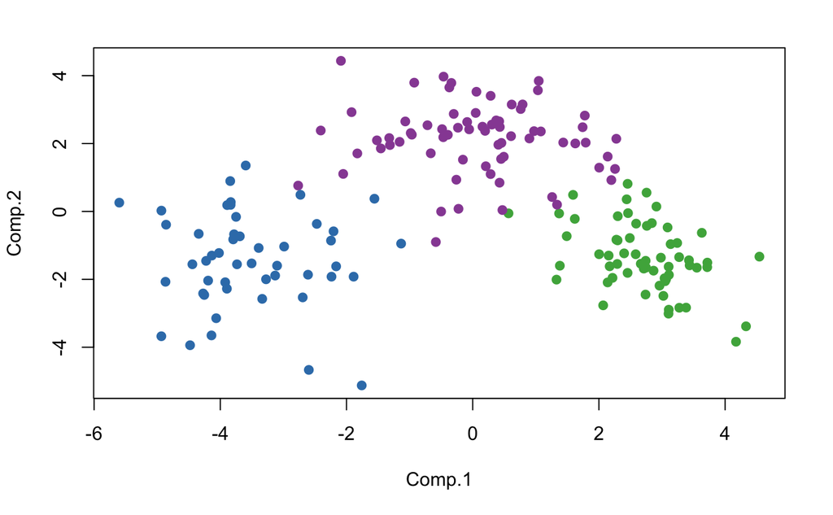

```r
plot(predict(princomp(X)),col=out$class,pch=19)
```

Let’s take some time to look at the estimation of the different model parameters. Use the help page to see how to access this information.

```r
?hddc
out$prop
```

```
  Posterior probabilities of groups
      1     2     3
   0.27 0.337 0.393
```

```r
out$d
```

```
      Intrinsic dimensions of the classes:
       1 2 3
  dim: 8 8 9
```

```r
out$a
```

```
Class   a1   a2   a3   a4   a5    a6    a7    a8    a9
    1 3.46 3.12 1.81 1.65 1.47 1.214 1.033 0.909     .
    2 2.96 1.95 1.69 1.37 1.11 0.919 0.843 0.737     .
    3 3.43 2.81 2.19 2.07 1.39 1.125 1.064 0.913 0.758
```

```r
out$b
```

```
        1     2     3
Bk: 0.189 0.198 0.232
```

```r
out$BIC
```

```
[1] -12893.57
```

## 3.2 - Model selection in HDDC

Model selection in *HDDC* concerns both the choice of the submodels and the intrinsic dimension estimation. Let’s start with the choice of submodels.

```r
out = hddc(X,3,model = 'all')
```

```
HDDC:
       model K threshold        BIC
1      AJBQD 3       0.2 -12,135.80
2       ABQD 3       0.2 -12,142.45
3      ABQKD 3       0.2 -12,380.15
4     AKBQKD 3       0.2 -12,387.69
5    AKJBQKD 3       0.2 -12,402.12
6     ABKQKD 3       0.2 -12,443.81
7    AKBKQKD 3       0.2 -12,450.21
8   AKJBKQKD 3       0.2 -12,602.41
9  AKJBKQKDK 3       0.2 -12,893.57
10  AKJBQKDK 3       0.2 -12,896.80
11   ABKQKDK 3       0.2 -12,944.94
12  AKBKQKDK 3       0.2 -12,948.23
13    ABQKDK 3       0.2 -12,948.24
14   AKBQKDK 3       0.2 -12,951.52

SELECTED: model  AJBQD  with  3  clusters.
Selection Criterion: BIC.
```

```r
table(out$class,cls)
```

```
   cls
     1  2  3
  1  0 67  0
  2 59  1  0
  3  0  3 48
```

```r
adjustedRandIndex(out$class,cls)
```

```
[1] 0.9325486
```

The choice of the intrisic dimensionalities is done through the Cattell’ scree test. The Cattell’s threshold is a value between 1 and 0 (lower values yield larger dimensionalities).

```r
out = hddc(X,3,threshold = c(0.2,0.15,0.1,0.05,0.01))
```

```
HDDC:
      model K threshold        BIC
1 AKJBKQKDK 3      0.15 -12,893.57
2 AKJBKQKDK 3      0.20 -12,893.57
3 AKJBKQKDK 3      0.10 -13,053.20
4 AKJBKQKDK 3      0.05 -13,540.34
5 AKJBKQKDK 3      0.01 -14,262.19

SELECTED: model  AKJBKQKDK  with  3  clusters.
Selection Criterion: BIC.
```

```r
table(out$class,cls)
```

```
   cls
     1  2  3
  1  1 69  0
  2  0  0 48
  3 58  2  0
```

```r
adjustedRandIndex(out$class,cls)
```

```
[1] 0.9459249
```

## 3.3 - Clustering of “real” HD data

We consider now the *USPS358* data set which are hadwritten digits represented as 256-dimensional vectors. The *USPS358* data set is a subset of the original *USPS* data set where only the digits 3, 5 and 8 have been kept.

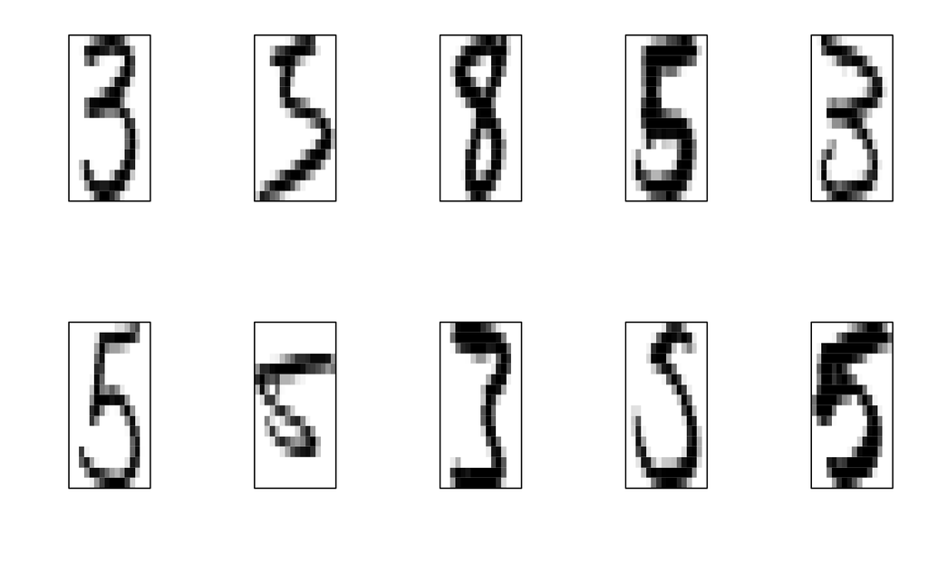

```r
load('data/USPS358.Rdata')
plotIm <- function(x){image(t(matrix(t(x),ncol=16,byrow=TRUE)[16:1,]),col=gray(255:0/255),axes=F); box()}
par(mfrow=c(2,5))
sel = sample(nrow(X),10)
for (i in 1:10) plotIm(X[sel[i],])
```

You can try clustering those data with *Mclust*…

```r
# TO DO!
out = Mclust(X,3,initialization=list(subset=sample(nrow(X),300)),verbose = FALSE)
table(out$classification,cls)
```

```
   cls
      1   2   3
  1  52 146 488
  2 149 123  12
  3 457 287  42
```

```r
adjustedRandIndex(out$classification,cls)
```

```
[1] 0.2809173
```

… and with *HDDC*.

```r
out = hddc(X,3)
```

```
      model K threshold         BIC
1 AKJBKQKDK 3       0.2 -613,317.19

SELECTED: model  AKJBKQKDK  with  3  clusters.
Selection Criterion: BIC.
```

```r
table(out$class,cls)
```

```
   cls
      1   2   3
  1  19   2 492
  2  43 549  26
  3 596   5  24
```

```r
adjustedRandIndex(out$class,cls)
```

```
[1] 0.8055273
```

We can look at the means that are estimated.

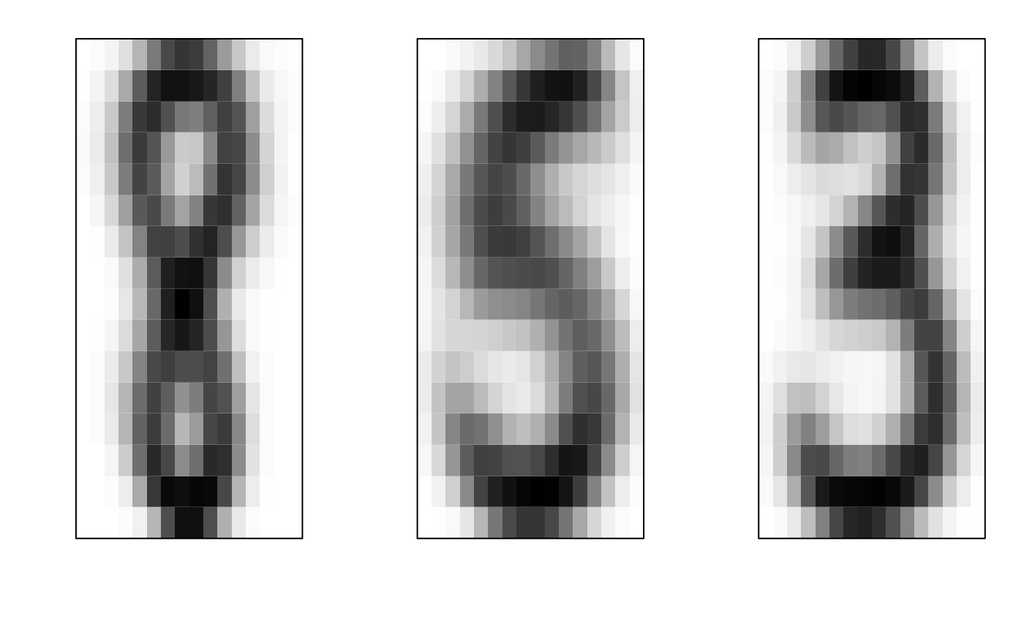

```r
par(mfrow=c(1,3))
for (k in 1:3) plotIm(out$mu[k,])
```

We can also try to improve the clustering by looking at submodels and playing with the group intrinsic dimensionalities.

```r
# TO DO!
out = hddc(X,3,model='all',threshold = c(0.2,0.15,0.1,0.05,0.01),mc.cores = 4)
```

```
HDDC:
       model K threshold           BIC
1   AKJBQKDK 3      0.01   -411,722.66
2  AKJBKQKDK 3      0.01   -420,425.62
3   AKJBKQKD 3      0.01   -420,666.29
4    AKJBQKD 3      0.01   -434,515.49
5    AKBKQKD 3      0.01   -442,748.82
6     ABKQKD 3      0.01   -443,236.25
7    AKBQKDK 3      0.01   -445,832.67
8     ABQKDK 3      0.01   -446,790.17
9    ABKQKDK 3      0.01   -452,467.94
10  AKBKQKDK 3      0.01   -452,486.06
11     ABQKD 3      0.01   -457,392.77
12    AKBQKD 3      0.01   -462,355.83
13   ABKQKDK 3      0.05   -496,195.50
```

[output cut: 60 more lines]

```r
table(out$class,cls)
```

```
   cls
      1   2   3
  1  21  90 487
  2 308 262  25
  3 329 204  30
```

```r
adjustedRandIndex(out$class,cls)
```

```
[1] 0.3124036
```

# 4 - Discriminative and sparse clustering

## 4.1 - The Fisher-EM algorithm for dscriminative clustering

We now consider the discriminative clustering method *Fisher-EM*, which is implemendted in the *FisherEM* package. First, let’s come back to a simpler HD data set: the *wine27* set.

```r
load('data/Wine27.Rdata')
library(FisherEM)
out = fem(X,3)
table(out$cls,cls)
```

```
   cls
     1  2  3
  1 59  2  0
  2  0  1 48
  3  0 68  0
```

```r
adjustedRandIndex(out$cls,cls)
```

```
[1] 0.9471318
```

## 4.2 - The sparse Fisher-EM algorithm: clustering and variable selection

The package can also perform variable selection while clustering data. The `sfem` function implements the sparse version of Fisher-EM.

```r
out = sfem(X,3,l1 = 0.3,model='all')
table(out$cls,cls)
```

```
   cls
     1  2  3
  1  0  1 48
  2 58  1  0
  3  1 69  0
```

```r
adjustedRandIndex(out$cls,cls)
```

```
[1] 0.9471756
```

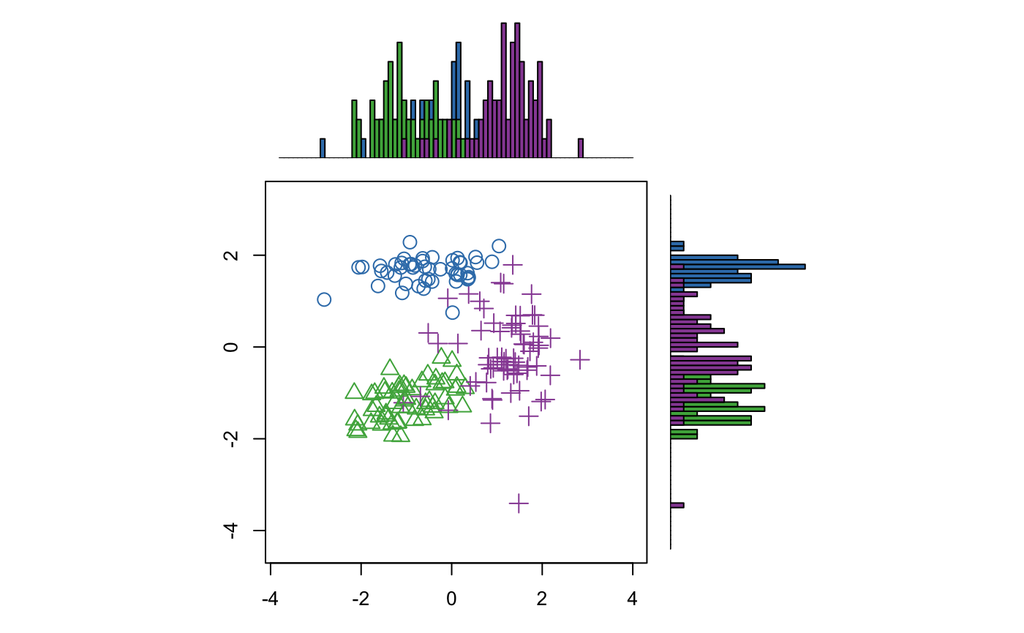

```r
plot(out)
```

```r
class(out$U) = "loadings"
out$U
```

```
Loadings:
                             U1     U2
Alcohol                      -0.930
Sugar-free_extract
Fixed_acidity
Tartaric_acid
Malic_acid
Uronic_acids
pH
Ash
Alcalinity_of_ash
Potassium
Calcium
Magnesium
Phosphate
Chloride
Total_phenols
Flavanoids                          -0.912
Nonflavanoid_phenols
Proanthocyanins
Color_Intensity              -0.364
Hue
OD280/OD315_of_diluted_wines        -0.411
OD280/OD315_of_flavanoids
Glycerol
2-3-butanediol
Total_nitrogen
Proline
Methanol

                  U1    U2
SS loadings    1.000 1.000
Proportion Var 0.037 0.037
Cumulative Var 0.037 0.074
```